# More Monte Carlo

Lecture 25

March 25, 2026

# Review

## Monte Carlo

- Stochastic simulation: propagate random variables $X$ through model $f$ and want to estimate $\mathbb{E}[f(X)] \approx \sum_{i=1}^n f(X_i)$ using samples $X_1, \ldots, X_n$.
- Example: probability of a standard Gaussian between $[0.8, 0.9]$: draw $X_1, \ldots, X_n \sim N(0, 1)$,
  $$f(x) = \mathbb{I}_{[0.8, 0.9]}(x).$$

## Statistics of Monte Carlo

- Denote $Y = f(X)$, $\mathbb{E}[Y] = \mu$, and $\sum_{i=1}^n Y_i = \tilde{\mu}_n$.
- MC is **unbiased**: $\mathbb{E}[\tilde{\mu}_n] = \mu$;
- Monte Carlo standard error (MCSE): $Y_i$ i.i.d., then $\text{SE}(\tilde{\mu}_n) = \sigma_Y / \sqrt{n}$.

## When Would We Want To Use Monte Carlo?

1. Ugly integrands: $f(X)$ is highly nonlinear or not smooth;
2. Ugly domains;
3. Higher dimensions;
4. Distribution of $X$ is implicit.

# Monte Carlo Confidence Intervals

## Monte Carlo Confidence Intervals

**Basic Idea**: The *Central Limit Theorem* says that with enough samples, the errors are normally distributed:

$$\left\|\tilde{\mu}_n - \mu\right\| \to \mathcal{N}\left(0, \frac{\sigma_Y^2}{n}\right)$$

## Monte Carlo Confidence Intervals

The $\alpha$-confidence interval is:
$$\tilde{\mu}_n \pm \Phi^{-1}\left(1 - \frac{\alpha}{2}\right) \frac{\sigma_Y}{\sqrt{n}}$$

For example, the 95% confidence interval is
$$\tilde{\mu}_n \pm 1.96 \frac{\sigma_Y}{\sqrt{n}}.$$

## Sidebar: Estimating $\sigma_Y$

We don’t know the population standard deviation $\sigma_Y$.

But we can estimate it using the simulation variance:

$$\begin{aligned}
\tilde{\sigma}^2_n &= \frac{1}{n-1} \mathbb{V}\left[Y_i\right] \\
&= \frac{1}{n-1} \sum_{i=1}^n \left(Y_i - \tilde{\mu}_n\right)^2
\end{aligned}$$

## How Many Samples Do I Need?

but we can’t even estimate $\mathbb{V}\left[Y_i\right]$ without doing Monte Carlo!

## How Many Samples Do I Need?

Try:

1. Run a “pilot” MC with a relatively small number of samples to estimate $\mathbb{V}\left[Y_i\right]$.
2. Pick a target MCSE $\varepsilon$, then we need $N \approx \mathbb{V}\left[Y_i\right] / \varepsilon^2$ samples.
3. Run the “real” MC with sample size $N$ and check if the MCSE is right ($N$ might be off due to error in the variance estimate).
4. If not, run more.

## Implications of Monte Carlo Error

Converging at a rate of $1/\sqrt{n}$ is not great. But:

- All models are wrong, and so there always exists some irreducible model error.
- We often need a lot of simulations. Do we have enough computational power?

# Estimating Quantiles with Monte Carlo

## MC Estimate of the CDF

Would like to estimate the CDF $F$ with some approximation $\hat{F}_n$, then compute $\hat{z}^\alpha_n = \hat{F}_n^{-1}(\alpha)$ as an estimator of the $\alpha$-quantile $z^\alpha$.

Given samples $\hat{\mathbf{y}} = y_1, \ldots, y_n \sim F$, define
$$\hat{F}_(y) = \frac{1}{n} \sum_{i=1}^n \mathbb{I}(y_i \leq y).$$

## Is This An Unbiased Estimator?

$$\begin{align*}
\mathbb{E}[\hat{F}_(y)] &= \frac{1}{n} \sum_{i=1}^n \mathbb{I}(y_i \leq y) \\
&= \frac{1}{n} \sum_{i=1}^n \mathbb{P}(y_i \leq y) \\
&= F(y)
\end{align*}$$

## Monte Carlo Quantile Estimation Error

From the CLT and some (not super important) theory about order statistics:
$$\text{Var}(\hat{z}^\alpha_n) \to \frac{\sigma^2_y}{n}\frac{\alpha (1 - \alpha)}{f^2(z^\alpha)}$$

In other words, **the smaller the density at the “true” quantile $z^\alpha$, the greater the error and the more samples required**.

# More Advanced Monte Carlo Methods (Teasers)

## Can We Reduce Sample Size?

Some approaches:

1. Control variates;
2. Antithetic variates;
3. Importance sampling.

## Control Variates

Idea is to “anchor” the estimate of $\mathbb{E}[f(X)]$ to some a similar but easier-to-calculate value $\mathbb{E}[g(X)]$.

## Anchoring

Let’s play a game:

Write down how long you think it takes to fly from London to New York.

What did you write down?

## Anchoring

Now suppose you know that it takes 8 hours and 15 minutes to fly from London to Washington, DC.

Write down how long you think it takes to fly from London to New York.

What did you write down?

## Anchoring and Control Variates

It’s easier to estimate a quantity if we can start with a known-but-similar value and tweak it slightly rather than estimating the quantity from scratch.

We want to estimate $\mu = \mathbb{E}[f(X)]$, but suppose we know $\mathbb{E}[g(X)]$ instead. Then:

$$\mu = \mathbb{E}[f(X)] = \mathbb{E}[f(X) - g(X) + g(X)] = \underbrace{\mathbb{E}[f(X) - g(X)]}_{\text{Estimate with MC}} + \underbrace{\mathbb{E}[g(X)]}_{\text{known}}.$$

## Control Variate Estimate

In other words, if $\nu = \mathbb{E}[g(X)]$, we can obtain an estimate

$$\tilde{\mu}_n^{\text{CV}} = \frac{1}{n} \left(f(X) - g(X)\right) + \nu.$$

The level of increased efficiency is related to the correlation between $f$ and $g$.

## Control Variate Example

Suppose we want to estimate $\mathbb{E}[\cos(X)]$, where $X \sim N(0, 1)$.

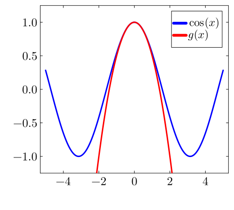

Figure 1: Control Variate Example Functions

```julia
x = -5:0.01:5
f(x) = cos(x)
g(x) = 1 - x^2/2

plot(x, f.(x), color=:blue, linewidth=3, label=L"$\cos(x)$")
plot!(x, g.(x), color=:red, linewidth=3, label=L"$g(x)$")
ylims!((-1.25, 1.25))
plot!(size=(500, 450))
```

## Control Variate Example

We know that if $X \sim N(\mu, \sigma^2)$, $\mathbb{E}[X^2] = \mu^2 + \sigma^2$, so $\mathbb{E}[g(X)] = 1/2$.

```julia
n = 1_000
X = rand(Normal(0, 1), n)
mu1 = mean(f.(X))
sigma1 = std(f.(X)) / sqrt(n)
mu2 = mean(f.(X) .- g.(X)) + 0.5
sigma2 = std(f.(X) .- g.(X)) / sqrt(n)
```

```
0.008243358365711412
```

1,000 samples:

Naive MC estimate: 0.5990591394024503 with MCSE 0.014265171495016033.

Control variate estimate: 0.6046790932663353 with MCSE 0.008243358365711412.

## Antithetic Variates

If target values of pairs of samples $h(X_i)$ and $h(Y_i)$ are negatively correlated, can increase rate of convergence of
$$\frac{1}{2M} \sum_{i=1}^M [h(X_i) + h(Y_i)]$$
relative to $\frac{1}{2M} h(X_i)$ alone:

$$\begin{aligned}
\mathbb{V}\left[\frac{1}{2}(h(X_i) + h(Y_i)\right] &= \frac{1}{4}\left[\mathbb{V}[h(X_i)] + \mathbb{V}[h(Y_i)] + 2\text{Cov}(h(X_i), h(Y_i)\right] \\
&= \frac{1}{4}\left(\sigma^2 + \sigma^2 + 2\rho\sigma^2) = \frac{1 + \rho}{2}\sigma^2
\end{aligned}$$

## Antithetic Variate Generation Can Be Difficult in Practice

- Ensuring anti-correlation can be difficult to verify in general;
- Gains in efficiency are dependent on effectiveness of antithetical variate generation and shape of $h(x)$

## What If We Can’t Sample From The Distribution?

- May not be able to generate samples $X \sim f(x)$ efficiently
- Think of sampling from tails:

$$P(X > k) \approx \frac{1}{M} \sum_{i=1}^M \mathbb{I}(X_i > k)$$

## Importance Sampling

Extension of rejection sampling without requiring “rejection”:

1. Draw samples from *importance distribution* g(x);
2. Reweight samples:
   $$\begin{align*}
   \mathbb{E}_f[h(x)] &= \int_x \frac{f(x)}{g(x)} g(x)h(x) dx \\
   &\approx \frac{1}{M} \sum_{i=1}^M \frac{f(x)}{g(x)}h(x)
   \end{align*}$$

## Importance Sampling Needs

Technically works with any proposal $g$, but more efficient if $g$ “covers” $f$ (like with rejection sampling):

$$f(x)/g(x) < M < \infty$$

# Key Points

## Key Points

- Monte Carlo is an unbiased estimator; confidence intervals given by CLT.
- Be mindful of Monte Carlo standard error for “naive” MC with iid samples.
- **Advanced**: Variance reduction techniques to improve convergence, see e.g. https://artowen.su.domains/mc/Ch-var-basic.pdf.

## Perhaps Most Importantly…

**Always report Monte Carlo error!**

# Upcoming Schedule

## Next Classes

**Wednesday**: The Bootstrap

# References